# Stat 135 Lab 12: One Way and Two Way ANOVA

## One Way Anova

### a) Create data

Manually type in the observations, and create a data frame with two columns - the observations and its group name.

```r
group1 <- c(279, 338, 334, 198, 303)
group2 <- c(378, 275, 412, 265, 286)
group3 <- c(172, 335, 335, 282, 250)
group4 <- c(381, 346, 340, 471, 318)
names <- rep(c('group1', 'group2', 'group3', 'group4'), each = 5)
dat <- data.frame(Obs = c(group1, group2, group3, group4), ind = names)
head(dat)
```

```
##   Obs    ind
## 1 279 group1
## 2 338 group1
## 3 334 group1
## 4 198 group1
## 5 303 group1
## 6 378 group2
```

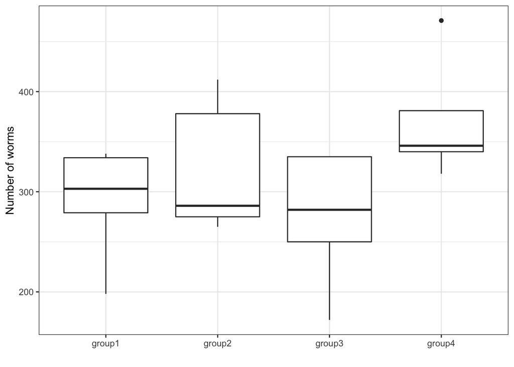

```r
# EDA ... Boxplot of each group
ggplot(dat, aes(x = ind, y = Obs)) +
  geom_boxplot() +
  xlab("") + ylab("Number of worms") +
  theme_bw()
```

```r
# Histogram of each group
# ggplot(dat, aes(x = Obs)) +
#   geom_histogram() +
#   facet_grid(~ ind)

# check for normality
# qqnorm(dat$Obs[dat$ind == "group1"])

# Variance for each group
# dat %>%
#   group_by(ind) %>%
#   summarise(var = var(Obs))
```

### b) Test for differences among the four groups

Use both the F test and the Kruskal-Wallis test in R to see whether there are significant differences among the four groups. Do you reach different conclusions? Which test is more approriate for this data set?

The difference between F test and the Kruskall-Wallis test has to do with the assumptions. Recall that F test assumes the following:

1. Data is normally distributed
2. Variance is homogenous across groups
3. Data are independent (within and across groups)

On the other hand, Krsukall test has a more relaxed assumption. It is a nonparametric approach, meaning that the data does not need to be normally distributed. In this case, we only have five data points in each group, so it is hard to assess whether data is normally distributed. Because of this, perhaps it makes sense to use the Krsukal test.

```r
# Analysis of Variance
fit <- aov(Obs ~ ind, data = dat)
summary(fit)
```

```
##             Df Sum Sq Mean Sq F value Pr(>F)
## ind          3  27234    9078   2.271  0.119
## Residuals   16  63954    3997
```

```r
kruskal.test(Obs ~ ind, data = dat)
```

```
##
##  Kruskal-Wallis rank sum test
##
## data:  Obs by ind
## Kruskal-Wallis chi-squared = 6.2047, df = 3, p-value = 0.1021
```

## Bonferroni vs Tukey

Previous two tests suggested that none of the pairs seem to be significantly different from each other. If there was a significant difference, a natural next step is to see which one of the pairs is significantly different from each other. One way to assess this is by constructing a confidence interval associated with the estimated difference in each pair, and see which one does or doesn't contain zero.

Q. Calculate simultaneous 95% confident intervals for all pairwise differences using both Bonferroni and Tukey’s method. Visualizes the CIs using ggplot.

Recall that the Bonferroni corrected confidence intervals are given in the expression below:
$$\bar{Y}_{i.} - \bar{Y}_{r.} \pm t_{n_i + n_r - 2, \frac{\alpha'}{2}} \sqrt{S_{ir}^2 \bigg(\frac{1}{n_i} + \frac{1}{n_r} \bigg)}$$
where $\alpha' = 2 \alpha / (k(k-1))$

Bonferroni method provides conservative confidence intervals — they provide less precise estimates but limits the probability that one or more of the confidence intervals does not contain the parameter to a maximum of 5%.

### a) Bonferroni CI

```r
## First define a function that takes in a pair and observations
## computes the confidence interval


# pair <- combn(k, 2)[, 1]
# Observations <- dat_list

get_pair_diff_CI <- function(pair, Observations, alpha = 0.05){
  # Extract the observations for the desired groups
  vec1 = Observations[[pair[1]]]
  vec2 = Observations[[pair[2]]]

  # bookkeeping
  center1 = mean(vec1)
  center2 = mean(vec2)
  n1 = length(vec1)
  n2 = length(vec2)
  k = length(Observations); m = k*(k-1)/2

  # Get CI bounds
  Sp2 = {(n1-1)*var(vec1) + (n2-1)*var(vec2)}/(n1+n2-2)
  halfwidth = qt(1-(alpha/2)/m, df = n1+n2-2, lower.tail = T) * sqrt(Sp2 * (1/n1+1/n2))
  return(c(center1-center2,
           center1-center2-halfwidth,
           center1-center2+halfwidth))
}
```

```r
# Apply the function to all combinations of pairs
k = 4
dat_list = list(group1, group2, group3, group4)
CIs = apply(combn(k, 2), 2, get_pair_diff_CI, dat_list)
combn(k, 2)
```

```
##      [,1] [,2] [,3] [,4] [,5] [,6]
## [1,]    1    1    1    2    2    3
## [2,]    2    3    4    3    4    4
```

```r
CIs # 3 x 6 matrix
```

```
##           [,1]      [,2]       [,3]      [,4]       [,5]       [,6]
## [1,]  -32.8000   15.6000  -80.80000   48.4000  -48.00000  -96.40000
## [2,] -169.7106 -122.4111 -209.77214 -100.1477 -188.18977 -237.66477
## [3,]  104.1106  153.6111   48.17214  196.9477   92.18977   44.86477
```

```r
# Create a character vector for each pair
# We will later use this to label our graph
pair_names = apply(combn(k, 2), 2,
      function(pair) paste0(unique(names)[pair[1]],'-', unique(names)[pair[2]]))

# Combine pair names and CIs in a data frame
CI_df <- data.frame(lab = pair_names, Diff = CIs[1,], lower = CIs[2,], upper = CIs[3,])
CI_df
```

```
##             lab  Diff     lower     upper
## 1 group1-group2 -32.8 -169.7106 104.11058
## 2 group1-group3  15.6 -122.4111 153.61113
## 3 group1-group4 -80.8 -209.7721  48.17214
## 4 group2-group3  48.4 -100.1477 196.94773
## 5 group2-group4 -48.0 -188.1898  92.18977
## 6 group3-group4 -96.4 -237.6648  44.86477
```

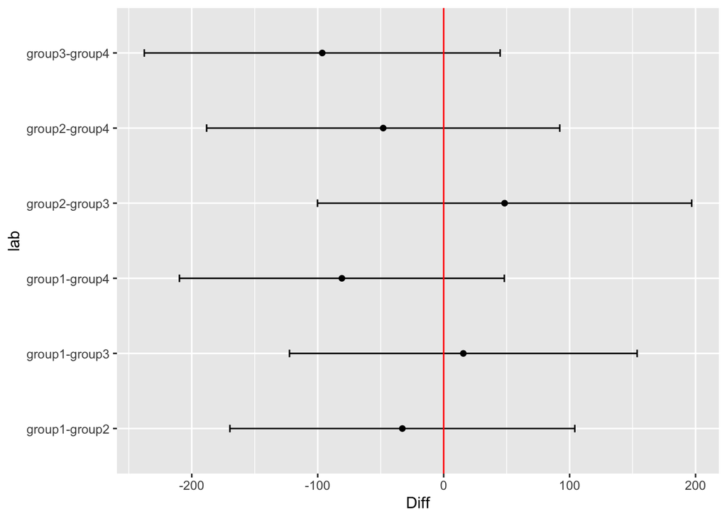

```r
ggplot(CI_df, aes(x = lab, y = Diff)) + geom_point() +
  geom_errorbar(width = 0.1, aes(ymin = lower, ymax = upper)) +
  geom_hline(yintercept = 0, col = 2)+
  coord_flip()
```

```r
# All CIs overlap with each other, suggesting that none of the pairs are significantly different from each other. This confirms the hypothesis test results that we obtained earlier.
```

### b) Tukey's HSD

Tukey's Honest Significant Difference test is another method for constructing simultaneous confidence intervals. Simultaneous $(1 - \alpha) \times 100\%$ Cis for pairwise differences are given:
$$\bar{Y}_{i.} - \bar{Y}_{r.}
\pm
q_{k, n-k}(\alpha)
\sqrt{MS_{W} \bigg(\frac{1}{n_i} + \frac{1}{n_r} \bigg)}$$

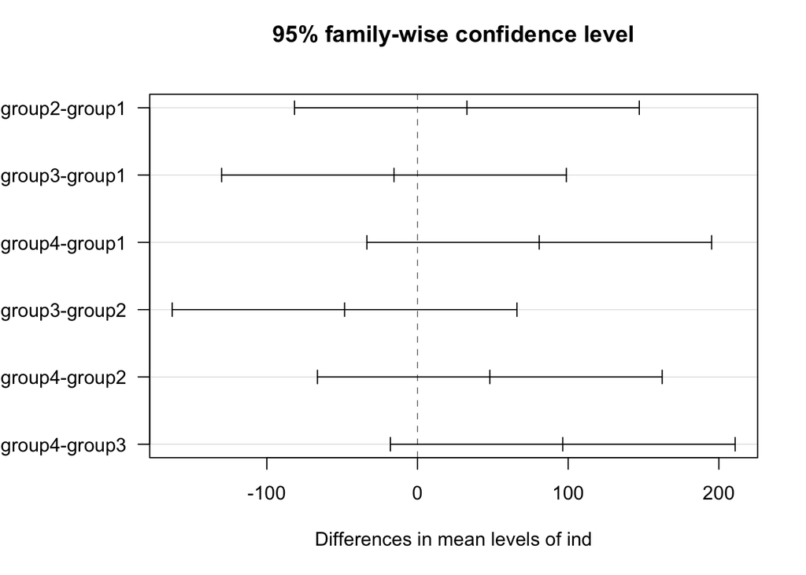

```r
posthoc <- TukeyHSD(x=fit, which = 'ind', conf.level=0.95)
par(mar=c(5.1, 6.5, 4.1, 2.1))  # Increase left margin so that group names can show
plot(posthoc, las = 1)
```

```r
par(mar=c(5.1, 4.1, 4.1, 2.1))
```

Both Bonferroni and Tukey methods control for the family wise error rate to be at most $\alpha$. Bonferroni method tends to produce overly conservative (i.e. overly wide) CIs, and so Tukey's HSD is considered to be a preferred method for examining all possible pairwise comparisons.

## Two Way Anova

Thus far, we have worked with one way ANOVA and our goal had been to assess any significant differenct in means across multiple groups. We had one factor to consider, which was groups. Here, we consider a more complex setting. In two way ANOVA, there are two factors of interest. We want to understand how the two factors simultaneously are associated with the dependent variable.

### a) Create data

Manually type in the observations, and create a data frame with three columns - the observations and its treatment levels.

```r
p <- 3
cell_names <- expand.grid(cycle_times = c(40, 50, 60), operator = c(1,2,3))
repeats <- rep(1:nrow(cell_names), each = p)
Cell_names <- cell_names[repeats, ]
Obs <- c(24, 23, 28, 37, 39, 35, 26, 29, 25,
         38, 36, 35, 34, 38, 36, 36, 37, 34,
         34, 36, 39, 34, 36, 31, 28, 26, 24)
Obs_w_names <- data.frame(cycle_times = factor(Cell_names$cycle_times),
                      operator = factor(Cell_names$operator), Obs = Obs)
head(Obs_w_names, 6)
```

```
##   cycle_times operator Obs
## 1          40        1  24
## 2          40        1  23
## 3          40        1  28
## 4          50        1  37
## 5          50        1  39
## 6          50        1  35
```

### b) Treatment Means Plot

Examine the Treatment Means Plot to visually asess whether there are interaction effects.

The treatment means plot plots mean score against cycles, for different operators. If there is no interaction between cycles and operators, then we should see parallel lines across groups, suggesting that the effect of cycle on means is the same across groups. Here, the line are not parallel with each other, suggesting that the effect of cycle on means is different across groups.

```r
Cell_means <- aggregate(Obs ~ cycle_times + operator, data = Obs_w_names, FUN = mean)

# Alternative way to get the cell means
Obs_w_names %>%
  group_by(cycle_times, operator) %>%
  summarise(mean = mean(Obs))
```

```
## # A tibble: 9 x 3
## # Groups:   cycle_times [3]
##   cycle_times operator  mean
##   <fct>       <fct>    <dbl>
## 1 40          1         25
## 2 40          2         36.3
## 3 40          3         36.3
## 4 50          1         37
## 5 50          2         36
## 6 50          3         33.7
## 7 60          1         26.7
## 8 60          2         35.7
## 9 60          3         26
```

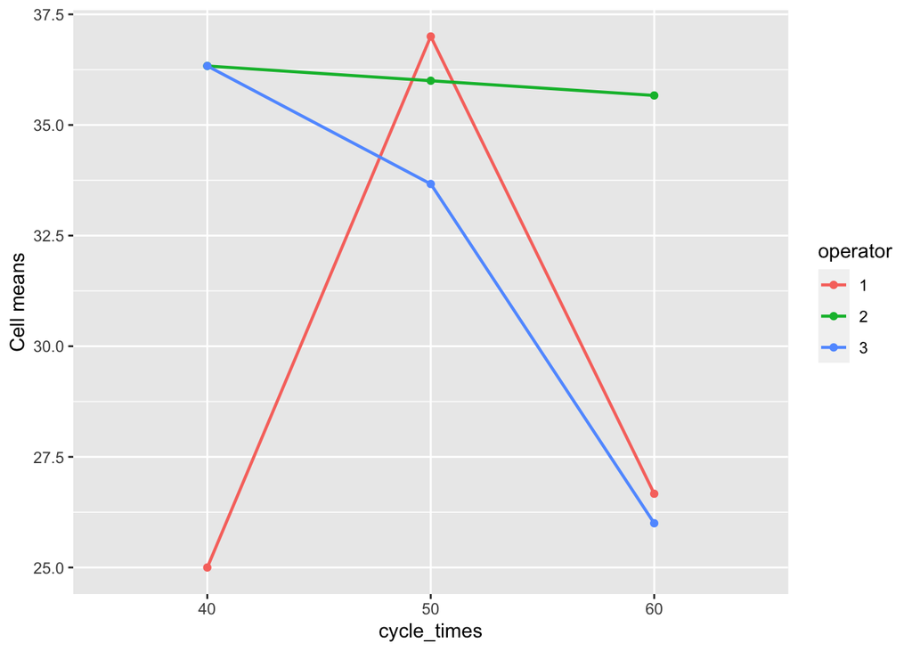

```r
# Plot cell means against cycle times, for each operator
ggplot(data=Cell_means,
    aes(x=cycle_times, y=Obs, group=operator, color=operator)) +
  geom_line(size = 0.8) + geom_point() + ylab("Cell means")
```

### c) Two Way ANOVA

Obtain the two-way ANOVA table in R.

It helps to first note that ANOVA and linear regression are mathematically identical. Both break down the variation in the data into different portions and assess the equality of the mean between them. A difference is that in ANOVA, the independent variable can only be categorical, e.g. group number. However, in linear regression, the independent variable can either be categorical or continuous. Linear regression can also have multiple independent variables, not just one or two. In a sense, linear regression is a general method and ANOVA is a special case of regression.

Here, we run a linear regression with main and interaction effects using lm function (which stands for linear model). lm function takes in mainly two arguments: formula and data. The coefficient $\beta'_{C_2}$, for example, tells us the strength of association between $C_2$ and $Y$, controlling for other variables.

$$Y
= \beta'_0 + \beta'_{C_2} C_2 + \beta'_{C_3} C_3 + \beta'_{O_2} O_2 + \beta'_{O_3} O_3 \\
+ \beta'_{2,2} C_2 O_2 + \beta'_{2,3} C_2 O_3
+ \beta'_{3,2} C_3 O_2 + \beta'_{3,3} C_3 O_3
+ \varepsilon' \;\; \text{... mod}$$
The effect of $C_2$ on $Y$ varies depending on which operator the observation comes from. For example, if the obesrvation is in $O_1$, then $O_2$ and $O_3$ would take values 0 and the effect of $C_2$ would just be $\beta_0' + \beta'_{C_2}$. If the observation was measured in $O_2$, then the effect of $C_2$ on $Y$ would now be $\beta_0' + \beta'_{C_2} +\beta'_{O_2} + \beta'_{2,2}$. Expressing interaction terms as a product of the two variables allows us to express the effect dynamically.

Note that anova and linear regression report their results in a different way. The linear regression reports the estimated coefficients of the individual variables. On the other hand, anova reports the anova table, which contain anova-specific information like the sum of squares and F value for each grouping of variables. For this data, anova output tells us that all grouping of variables, i.e. cycle, operator, and the interaction explain significant amount of variation in dye score.

```r
mod = lm(Obs ~ cycle_times + operator + cycle_times * operator, data = Obs_w_names)
# mod = lm(cycle_times * operator, data = Obs_w_names) runs the same regression
# just having the interaction term is fine. R automatically knows it to expand the formula into main and interaction effects.

summary(mod)
```

```
##
## Call:
## lm(formula = Obs ~ cycle_times + operator + cycle_times * operator,
##     data = Obs_w_names)
##
## Residuals:
##    Min     1Q Median     3Q    Max
## -2.667 -1.667  0.000  1.833  3.000
##
## Coefficients:
##                         Estimate Std. Error t value Pr(>|t|)
## (Intercept)               25.000      1.227  20.371 7.01e-14 ***
## cycle_times50             12.000      1.736   6.914 1.83e-06 ***
## cycle_times60              1.667      1.736   0.960 0.349639
## operator2                 11.333      1.736   6.530 3.88e-06 ***
## operator3                 11.333      1.736   6.530 3.88e-06 ***
## cycle_times50:operator2  -12.333      2.455  -5.025 8.80e-05 ***
## cycle_times60:operator2   -2.333      2.455  -0.951 0.354385
## cycle_times50:operator3  -14.667      2.455  -5.975 1.19e-05 ***
## cycle_times60:operator3  -12.000      2.455  -4.889 0.000118 ***
## ---
## Signif. codes:  0 '***' 0.001 '**' 0.01 '*' 0.05 '.' 0.1 ' ' 1
##
## Residual standard error: 2.126 on 18 degrees of freedom
## Multiple R-squared:  0.8836, Adjusted R-squared:  0.8319
## F-statistic: 17.08 on 8 and 18 DF,  p-value: 6.194e-07
```

```r
print(anova(mod))
```

```
## Analysis of Variance Table
##
## Response: Obs
##                      Df  Sum Sq Mean Sq F value    Pr(>F)
## cycle_times           2 168.074  84.037  18.598 4.171e-05 ***
## operator              2 190.519  95.259  21.082 1.921e-05 ***
## cycle_times:operator  4 258.815  64.704  14.320 2.005e-05 ***
## Residuals            18  81.333   4.519
## ---
## Signif. codes:  0 '***' 0.001 '**' 0.01 '*' 0.05 '.' 0.1 ' ' 1
```

### d) Check for interaction effect

Use anova() to test whether there is any interaction effect.

```r
# Run two regression models, one with interaction and the other without
mod = lm(Obs ~ cycle_times * operator, data = Obs_w_names)
mod_0 = lm(Obs ~ cycle_times + operator, data = Obs_w_names)

# Look at F statistic in each
summary(mod)
```

```
##
## Call:
## lm(formula = Obs ~ cycle_times * operator, data = Obs_w_names)
##
## Residuals:
##    Min     1Q Median     3Q    Max
## -2.667 -1.667  0.000  1.833  3.000
##
## Coefficients:
##                         Estimate Std. Error t value Pr(>|t|)
## (Intercept)               25.000      1.227  20.371 7.01e-14 ***
## cycle_times50             12.000      1.736   6.914 1.83e-06 ***
## cycle_times60              1.667      1.736   0.960 0.349639
## operator2                 11.333      1.736   6.530 3.88e-06 ***
## operator3                 11.333      1.736   6.530 3.88e-06 ***
## cycle_times50:operator2  -12.333      2.455  -5.025 8.80e-05 ***
## cycle_times60:operator2   -2.333      2.455  -0.951 0.354385
## cycle_times50:operator3  -14.667      2.455  -5.975 1.19e-05 ***
## cycle_times60:operator3  -12.000      2.455  -4.889 0.000118 ***
## ---
## Signif. codes:  0 '***' 0.001 '**' 0.01 '*' 0.05 '.' 0.1 ' ' 1
##
## Residual standard error: 2.126 on 18 degrees of freedom
## Multiple R-squared:  0.8836, Adjusted R-squared:  0.8319
## F-statistic: 17.08 on 8 and 18 DF,  p-value: 6.194e-07
```

```r
summary(mod_0)
```

```
##
## Call:
## lm(formula = Obs ~ cycle_times + operator, data = Obs_w_names)
##
## Residuals:
##     Min      1Q  Median      3Q     Max
## -6.5926 -2.2593 -0.4815  2.4630  6.9630
##
## Coefficients:
##               Estimate Std. Error t value Pr(>|t|)
## (Intercept)     29.593      1.692  17.489 2.16e-14 ***
## cycle_times50    3.000      1.854   1.618  0.11981
## cycle_times60   -3.111      1.854  -1.678  0.10742
## operator2        6.444      1.854   3.477  0.00214 **
## operator3        2.444      1.854   1.319  0.20082
## ---
## Signif. codes:  0 '***' 0.001 '**' 0.01 '*' 0.05 '.' 0.1 ' ' 1
##
## Residual standard error: 3.932 on 22 degrees of freedom
## Multiple R-squared:  0.5132, Adjusted R-squared:  0.4247
## F-statistic: 5.798 on 4 and 22 DF,  p-value: 0.002418
```

```r
# Anova helps us assess if the increase in sum of squares is significant
anova(mod_0, mod, test='F')
```

```
## Analysis of Variance Table
##
## Model 1: Obs ~ cycle_times + operator
## Model 2: Obs ~ cycle_times * operator
##   Res.Df    RSS Df Sum of Sq     F    Pr(>F)
## 1     22 340.15
## 2     18  81.33  4    258.81 14.32 2.005e-05 ***
## ---
## Signif. codes:  0 '***' 0.001 '**' 0.01 '*' 0.05 '.' 0.1 ' ' 1
```

### e) Tukey multiple Pairwise Comparisons

Perform Tukey multiple pairwise-comparisons for the variable operator. From the simultaneous CIs, can you see which operator had the best score?

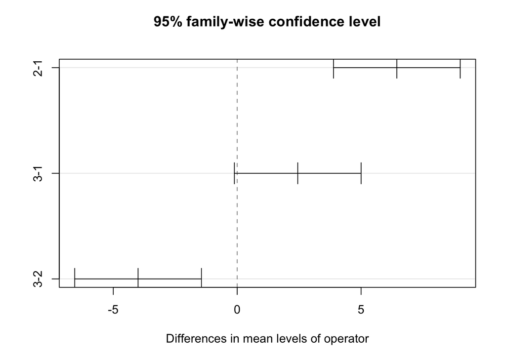

```r
res.aov = aov(Obs ~ cycle_times * operator, data = Obs_w_names)
posthoc = TukeyHSD(x=res.aov, which = 'operator',  conf.level=0.95)
plot(posthoc)
```

```r
# operator 2 seems to have the best score
```